# Risk Factor Analysis

## Outcome Variable

**Outcome Variable:** y_rate_len

## Predictor Variables

**Intervention Variable:** predfeed3

**Adjustment Set:**

unadjusted

## Stratifying Variables

The analysis was stratified on these variable(s):

- agecat
- studyid
- country

## Data Summary

| agecat | studyid | country | predfeed3 | n_cell | n |
| --- | --- | --- | --- | --- | --- |
| 0-3 months | EE | PAKISTAN | 1 | 31 | 31 |
| 0-3 months | EE | PAKISTAN | 0 | 0 | 31 |
| 0-3 months | GMS-Nepal | NEPAL | 1 | 378 | 456 |
| 0-3 months | GMS-Nepal | NEPAL | 0 | 78 | 456 |
| 0-3 months | MAL-ED | BANGLADESH | 1 | 193 | 237 |
| 0-3 months | MAL-ED | BANGLADESH | 0 | 44 | 237 |
| 0-3 months | MAL-ED | BRAZIL | 1 | 73 | 147 |
| 0-3 months | MAL-ED | BRAZIL | 0 | 74 | 147 |
| 0-3 months | MAL-ED | INDIA | 1 | 113 | 164 |
| 0-3 months | MAL-ED | INDIA | 0 | 51 | 164 |
| 0-3 months | MAL-ED | NEPAL | 1 | 81 | 153 |
| 0-3 months | MAL-ED | NEPAL | 0 | 72 | 153 |
| 0-3 months | MAL-ED | PERU | 1 | 168 | 262 |
| 0-3 months | MAL-ED | PERU | 0 | 94 | 262 |
| 0-3 months | MAL-ED | SOUTH AFRICA | 1 | 58 | 203 |
| 0-3 months | MAL-ED | SOUTH AFRICA | 0 | 145 | 203 |
| 0-3 months | MAL-ED | TANZANIA, UNITED REPUBLIC OF | 1 | 57 | 197 |
| 0-3 months | MAL-ED | TANZANIA, UNITED REPUBLIC OF | 0 | 140 | 197 |
| 3-6 months | EE | PAKISTAN | 1 | 31 | 31 |
| 3-6 months | EE | PAKISTAN | 0 | 0 | 31 |
| 3-6 months | GMS-Nepal | NEPAL | 1 | 350 | 420 |
| 3-6 months | GMS-Nepal | NEPAL | 0 | 70 | 420 |
| 3-6 months | MAL-ED | BANGLADESH | 1 | 184 | 225 |
| 3-6 months | MAL-ED | BANGLADESH | 0 | 41 | 225 |
| 3-6 months | MAL-ED | BRAZIL | 1 | 93 | 186 |
| 3-6 months | MAL-ED | BRAZIL | 0 | 93 | 186 |
| 3-6 months | MAL-ED | INDIA | 1 | 146 | 206 |
| 3-6 months | MAL-ED | INDIA | 0 | 60 | 206 |
| 3-6 months | MAL-ED | NEPAL | 1 | 112 | 226 |
| 3-6 months | MAL-ED | NEPAL | 0 | 114 | 226 |

[output cut: 114 more lines]

The following strata were considered:

- agecat: 0-3 months, studyid: EE, country: PAKISTAN
- agecat: 0-3 months, studyid: GMS-Nepal, country: NEPAL
- agecat: 0-3 months, studyid: MAL-ED, country: BANGLADESH
- agecat: 0-3 months, studyid: MAL-ED, country: BRAZIL
- agecat: 0-3 months, studyid: MAL-ED, country: INDIA
- agecat: 0-3 months, studyid: MAL-ED, country: NEPAL
- agecat: 0-3 months, studyid: MAL-ED, country: PERU
- agecat: 0-3 months, studyid: MAL-ED, country: SOUTH AFRICA
- agecat: 0-3 months, studyid: MAL-ED, country: TANZANIA, UNITED REPUBLIC OF
- agecat: 12-15 months, studyid: EE, country: PAKISTAN
- agecat: 12-15 months, studyid: GMS-Nepal, country: NEPAL
- agecat: 12-15 months, studyid: MAL-ED, country: BANGLADESH
- agecat: 12-15 months, studyid: MAL-ED, country: BRAZIL
- agecat: 12-15 months, studyid: MAL-ED, country: INDIA
- agecat: 12-15 months, studyid: MAL-ED, country: NEPAL
- agecat: 12-15 months, studyid: MAL-ED, country: PERU
- agecat: 12-15 months, studyid: MAL-ED, country: SOUTH AFRICA
- agecat: 12-15 months, studyid: MAL-ED, country: TANZANIA, UNITED REPUBLIC OF
- agecat: 15-18 months, studyid: EE, country: PAKISTAN
- agecat: 15-18 months, studyid: GMS-Nepal, country: NEPAL
- agecat: 15-18 months, studyid: MAL-ED, country: BANGLADESH
- agecat: 15-18 months, studyid: MAL-ED, country: BRAZIL
- agecat: 15-18 months, studyid: MAL-ED, country: INDIA
- agecat: 15-18 months, studyid: MAL-ED, country: NEPAL
- agecat: 15-18 months, studyid: MAL-ED, country: PERU
- agecat: 15-18 months, studyid: MAL-ED, country: SOUTH AFRICA
- agecat: 15-18 months, studyid: MAL-ED, country: TANZANIA, UNITED REPUBLIC OF
- agecat: 18-21 months, studyid: EE, country: PAKISTAN
- agecat: 18-21 months, studyid: GMS-Nepal, country: NEPAL
- agecat: 18-21 months, studyid: MAL-ED, country: BANGLADESH
- agecat: 18-21 months, studyid: MAL-ED, country: BRAZIL
- agecat: 18-21 months, studyid: MAL-ED, country: INDIA
- agecat: 18-21 months, studyid: MAL-ED, country: NEPAL
- agecat: 18-21 months, studyid: MAL-ED, country: PERU
- agecat: 18-21 months, studyid: MAL-ED, country: SOUTH AFRICA
- agecat: 18-21 months, studyid: MAL-ED, country: TANZANIA, UNITED REPUBLIC OF
- agecat: 21-24 months, studyid: EE, country: PAKISTAN
- agecat: 21-24 months, studyid: GMS-Nepal, country: NEPAL
- agecat: 21-24 months, studyid: MAL-ED, country: BANGLADESH
- agecat: 21-24 months, studyid: MAL-ED, country: BRAZIL
- agecat: 21-24 months, studyid: MAL-ED, country: INDIA
- agecat: 21-24 months, studyid: MAL-ED, country: NEPAL
- agecat: 21-24 months, studyid: MAL-ED, country: PERU
- agecat: 21-24 months, studyid: MAL-ED, country: SOUTH AFRICA
- agecat: 21-24 months, studyid: MAL-ED, country: TANZANIA, UNITED REPUBLIC OF
- agecat: 3-6 months, studyid: EE, country: PAKISTAN
- agecat: 3-6 months, studyid: GMS-Nepal, country: NEPAL
- agecat: 3-6 months, studyid: MAL-ED, country: BANGLADESH
- agecat: 3-6 months, studyid: MAL-ED, country: BRAZIL
- agecat: 3-6 months, studyid: MAL-ED, country: INDIA
- agecat: 3-6 months, studyid: MAL-ED, country: NEPAL
- agecat: 3-6 months, studyid: MAL-ED, country: PERU
- agecat: 3-6 months, studyid: MAL-ED, country: SOUTH AFRICA
- agecat: 3-6 months, studyid: MAL-ED, country: TANZANIA, UNITED REPUBLIC OF
- agecat: 6-9 months, studyid: EE, country: PAKISTAN
- agecat: 6-9 months, studyid: GMS-Nepal, country: NEPAL
- agecat: 6-9 months, studyid: MAL-ED, country: BANGLADESH
- agecat: 6-9 months, studyid: MAL-ED, country: BRAZIL
- agecat: 6-9 months, studyid: MAL-ED, country: INDIA
- agecat: 6-9 months, studyid: MAL-ED, country: NEPAL
- agecat: 6-9 months, studyid: MAL-ED, country: PERU
- agecat: 6-9 months, studyid: MAL-ED, country: SOUTH AFRICA
- agecat: 6-9 months, studyid: MAL-ED, country: TANZANIA, UNITED REPUBLIC OF
- agecat: 9-12 months, studyid: EE, country: PAKISTAN
- agecat: 9-12 months, studyid: GMS-Nepal, country: NEPAL
- agecat: 9-12 months, studyid: MAL-ED, country: BANGLADESH
- agecat: 9-12 months, studyid: MAL-ED, country: BRAZIL
- agecat: 9-12 months, studyid: MAL-ED, country: INDIA
- agecat: 9-12 months, studyid: MAL-ED, country: NEPAL
- agecat: 9-12 months, studyid: MAL-ED, country: PERU
- agecat: 9-12 months, studyid: MAL-ED, country: SOUTH AFRICA
- agecat: 9-12 months, studyid: MAL-ED, country: TANZANIA, UNITED REPUBLIC OF

### Dropped Strata

- agecat: 0-3 months, studyid: EE, country: PAKISTAN
- agecat: 3-6 months, studyid: EE, country: PAKISTAN
- agecat: 6-9 months, studyid: EE, country: PAKISTAN
- agecat: 9-12 months, studyid: EE, country: PAKISTAN
- agecat: 12-15 months, studyid: EE, country: PAKISTAN
- agecat: 15-18 months, studyid: EE, country: PAKISTAN
- agecat: 18-21 months, studyid: EE, country: PAKISTAN
- agecat: 21-24 months, studyid: EE, country: PAKISTAN

## Methods Detail

We’re interested in the causal parameters $E[Y_a]$ for all values of $a \in \mathcal{A}$. These parameters represent the mean outcome if, possibly contrary to fact, we intervened to set all units to have $A=a$. Under the randomization and positivity assumptions, these are identified by the statistical parameters $\psi_a=E_W[E_{Y|A,W}(Y|A=a,W)]$. In addition, we’re interested in the mean of $Y$, $E[Y]$ under no intervention (the observed mean). We will estimate these parameters by using SuperLearner to fit the relevant likelihood factors – $E_{Y|A,W}(Y|A=a,W)$ and $p(A=a|W)$, and then updating our likelihood fit using a joint TMLE.

For unadjusted analyses ($W=\{\}$), initial likelihoods were estimated using Lrnr_glm to estimate the simple $E(Y|A)$ and Lrnr_mean to estimate $p(A)$. For adjusted analyses, a small library containing Lrnr_glmnet, Lrnr_xgboost, and Lrnr_mean was used.

Having estimated these parameters, we will then use the delta method to estimate relative risks and attributable risks relative to a prespecified baseline level of $A$.

# Results Detail

## Results Plots

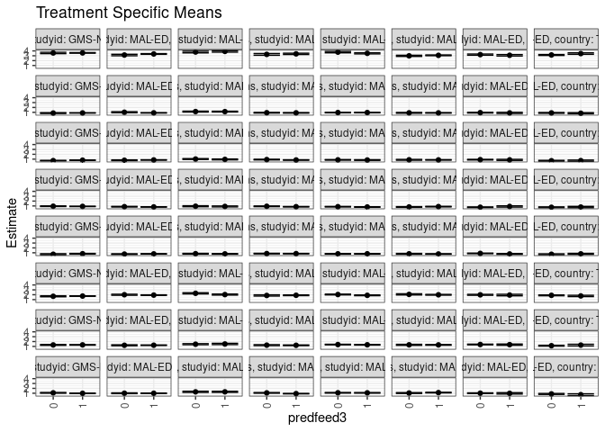

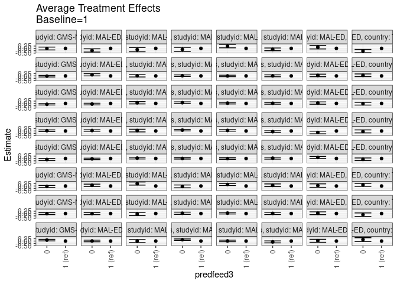

[figure not shown]

## Results Table

### Parameter: TSM

| agecat | studyid | country | intervention_level | baseline_level | estimate | ci_lower | ci_upper |
| --- | --- | --- | --- | --- | --- | --- | --- |
| 0-3 months | GMS-Nepal | NEPAL | 1 | NA | 3.5854097 | 3.5267502 | 3.6440691 |
| 0-3 months | GMS-Nepal | NEPAL | 0 | NA | 3.5730108 | 3.4337806 | 3.7122411 |
| 0-3 months | MAL-ED | BANGLADESH | 1 | NA | 3.3702323 | 3.2974462 | 3.4430185 |
| 0-3 months | MAL-ED | BANGLADESH | 0 | NA | 3.1535804 | 2.9984549 | 3.3087058 |
| 0-3 months | MAL-ED | BRAZIL | 1 | NA | 3.8983669 | 3.7423853 | 4.0543486 |
| 0-3 months | MAL-ED | BRAZIL | 0 | NA | 3.7691295 | 3.5986269 | 3.9396321 |
| 0-3 months | MAL-ED | INDIA | 1 | NA | 3.3919898 | 3.2596614 | 3.5243182 |
| 0-3 months | MAL-ED | INDIA | 0 | NA | 3.2830940 | 3.1047557 | 3.4614323 |
| 0-3 months | MAL-ED | NEPAL | 1 | NA | 3.4999584 | 3.3813905 | 3.6185263 |
| 0-3 months | MAL-ED | NEPAL | 0 | NA | 3.7442369 | 3.6041572 | 3.8843166 |
| 0-3 months | MAL-ED | PERU | 1 | NA | 3.0879346 | 3.0092929 | 3.1665763 |
| 0-3 months | MAL-ED | PERU | 0 | NA | 2.9862796 | 2.8635170 | 3.1090423 |
| 0-3 months | MAL-ED | SOUTH AFRICA | 1 | NA | 3.1019110 | 2.9561570 | 3.2476649 |
| 0-3 months | MAL-ED | SOUTH AFRICA | 0 | NA | 3.2342070 | 3.1093130 | 3.3591010 |
| 0-3 months | MAL-ED | TANZANIA, UNITED REPUBLIC OF | 1 | NA | 3.4481188 | 3.2993201 | 3.5969175 |
| 0-3 months | MAL-ED | TANZANIA, UNITED REPUBLIC OF | 0 | NA | 3.1637155 | 3.0667577 | 3.2606734 |
| 3-6 months | GMS-Nepal | NEPAL | 1 | NA | 1.7251375 | 1.6796800 | 1.7705949 |
| 3-6 months | GMS-Nepal | NEPAL | 0 | NA | 1.6795957 | 1.5808179 | 1.7783735 |
| 3-6 months | MAL-ED | BANGLADESH | 1 | NA | 1.9215515 | 1.8661384 | 1.9769647 |
| 3-6 months | MAL-ED | BANGLADESH | 0 | NA | 2.0009626 | 1.8920881 | 2.1098372 |
| 3-6 months | MAL-ED | BRAZIL | 1 | NA | 2.0301190 | 1.9190066 | 2.1412315 |
| 3-6 months | MAL-ED | BRAZIL | 0 | NA | 2.2918926 | 2.1711413 | 2.4126440 |
| 3-6 months | MAL-ED | INDIA | 1 | NA | 1.8890888 | 1.8084263 | 1.9697513 |
| 3-6 months | MAL-ED | INDIA | 0 | NA | 1.8489771 | 1.7216282 | 1.9763260 |
| 3-6 months | MAL-ED | NEPAL | 1 | NA | 1.8770027 | 1.8034500 | 1.9505554 |
| 3-6 months | MAL-ED | NEPAL | 0 | NA | 2.0425098 | 1.9589345 | 2.1260851 |
| 3-6 months | MAL-ED | PERU | 1 | NA | 1.9874581 | 1.9073345 | 2.0675818 |
| 3-6 months | MAL-ED | PERU | 0 | NA | 2.0673450 | 1.9488182 | 2.1858717 |
| 3-6 months | MAL-ED | SOUTH AFRICA | 1 | NA | 1.9336527 | 1.7788247 | 2.0884807 |
| 3-6 months | MAL-ED | SOUTH AFRICA | 0 | NA | 1.9797334 | 1.8821723 | 2.0772944 |

[output cut: 98 more lines]

### Parameter: E(Y)

| agecat | studyid | country | intervention_level | baseline_level | estimate | ci_lower | ci_upper |
| --- | --- | --- | --- | --- | --- | --- | --- |
| 0-3 months | GMS-Nepal | NEPAL | NA | NA | 3.5832888 | 3.5291425 | 3.6374351 |
| 0-3 months | MAL-ED | BANGLADESH | NA | NA | 3.3300100 | 3.2632400 | 3.3967800 |
| 0-3 months | MAL-ED | BRAZIL | NA | NA | 3.8333086 | 3.7172183 | 3.9493989 |
| 0-3 months | MAL-ED | INDIA | NA | NA | 3.3581259 | 3.2511263 | 3.4651254 |
| 0-3 months | MAL-ED | NEPAL | NA | NA | 3.6149130 | 3.5218465 | 3.7079794 |
| 0-3 months | MAL-ED | PERU | NA | NA | 3.0514630 | 2.9842485 | 3.1186774 |
| 0-3 months | MAL-ED | SOUTH AFRICA | NA | NA | 3.1964081 | 3.0976125 | 3.2952037 |
| 0-3 months | MAL-ED | TANZANIA, UNITED REPUBLIC OF | NA | NA | 3.2460048 | 3.1627741 | 3.3292354 |
| 3-6 months | GMS-Nepal | NEPAL | NA | NA | 1.7175472 | 1.6762113 | 1.7588831 |
| 3-6 months | MAL-ED | BANGLADESH | NA | NA | 1.9360220 | 1.8863911 | 1.9856528 |
| 3-6 months | MAL-ED | BRAZIL | NA | NA | 2.1610058 | 2.0768189 | 2.2451928 |
| 3-6 months | MAL-ED | INDIA | NA | NA | 1.8774058 | 1.8092128 | 1.9455987 |
| 3-6 months | MAL-ED | NEPAL | NA | NA | 1.9604886 | 1.9037186 | 2.0172585 |
| 3-6 months | MAL-ED | PERU | NA | NA | 2.0146923 | 1.9480408 | 2.0813438 |
| 3-6 months | MAL-ED | SOUTH AFRICA | NA | NA | 1.9673270 | 1.8846989 | 2.0499551 |
| 3-6 months | MAL-ED | TANZANIA, UNITED REPUBLIC OF | NA | NA | 1.8384078 | 1.7678309 | 1.9089846 |
| 6-9 months | GMS-Nepal | NEPAL | NA | NA | 1.3149164 | 1.2666599 | 1.3631729 |
| 6-9 months | MAL-ED | BANGLADESH | NA | NA | 1.2426951 | 1.2021480 | 1.2832422 |
| 6-9 months | MAL-ED | BRAZIL | NA | NA | 1.4793615 | 1.3932814 | 1.5654415 |
| 6-9 months | MAL-ED | INDIA | NA | NA | 1.2410939 | 1.1870908 | 1.2950970 |
| 6-9 months | MAL-ED | NEPAL | NA | NA | 1.3593977 | 1.3145109 | 1.4042846 |
| 6-9 months | MAL-ED | PERU | NA | NA | 1.3181643 | 1.2633979 | 1.3729307 |
| 6-9 months | MAL-ED | SOUTH AFRICA | NA | NA | 1.3866251 | 1.3204306 | 1.4528196 |
| 6-9 months | MAL-ED | TANZANIA, UNITED REPUBLIC OF | NA | NA | 1.1862735 | 1.1092792 | 1.2632679 |
| 9-12 months | GMS-Nepal | NEPAL | NA | NA | 0.9981577 | 0.9587526 | 1.0375629 |
| 9-12 months | MAL-ED | BANGLADESH | NA | NA | 0.9927203 | 0.9534705 | 1.0319702 |
| 9-12 months | MAL-ED | BRAZIL | NA | NA | 1.2871495 | 1.2069822 | 1.3673169 |
| 9-12 months | MAL-ED | INDIA | NA | NA | 0.9664571 | 0.9272553 | 1.0056589 |
| 9-12 months | MAL-ED | NEPAL | NA | NA | 1.0863279 | 1.0443920 | 1.1282637 |
| 9-12 months | MAL-ED | PERU | NA | NA | 1.0996556 | 1.0484043 | 1.1509069 |
| 9-12 months | MAL-ED | SOUTH AFRICA | NA | NA | 0.9974431 | 0.9321487 | 1.0627375 |
| 9-12 months | MAL-ED | TANZANIA, UNITED REPUBLIC OF | NA | NA | 0.8135761 | 0.7280408 | 0.8991114 |
| 12-15 months | GMS-Nepal | NEPAL | NA | NA | 0.8703223 | 0.8418462 | 0.8987983 |
| 12-15 months | MAL-ED | BANGLADESH | NA | NA | 0.9168218 | 0.8756400 | 0.9580036 |
| 12-15 months | MAL-ED | BRAZIL | NA | NA | 1.1479969 | 1.0880713 | 1.2079226 |
| 12-15 months | MAL-ED | INDIA | NA | NA | 0.9027484 | 0.8605827 | 0.9449141 |
| 12-15 months | MAL-ED | NEPAL | NA | NA | 0.9510803 | 0.9108264 | 0.9913342 |
| 12-15 months | MAL-ED | PERU | NA | NA | 0.8899324 | 0.8436019 | 0.9362629 |
| 12-15 months | MAL-ED | SOUTH AFRICA | NA | NA | 0.9200282 | 0.8606688 | 0.9793876 |
| 12-15 months | MAL-ED | TANZANIA, UNITED REPUBLIC OF | NA | NA | 0.8603058 | 0.7910045 | 0.9296071 |
| 15-18 months | GMS-Nepal | NEPAL | NA | NA | 0.7714871 | 0.7347479 | 0.8082263 |
| 15-18 months | MAL-ED | BANGLADESH | NA | NA | 0.8229575 | 0.7855057 | 0.8604093 |
| 15-18 months | MAL-ED | BRAZIL | NA | NA | 0.9818884 | 0.9203285 | 1.0434482 |
| 15-18 months | MAL-ED | INDIA | NA | NA | 0.8524809 | 0.8141426 | 0.8908193 |
| 15-18 months | MAL-ED | NEPAL | NA | NA | 0.8379671 | 0.7952249 | 0.8807093 |
| 15-18 months | MAL-ED | PERU | NA | NA | 0.8524194 | 0.8100116 | 0.8948273 |
| 15-18 months | MAL-ED | SOUTH AFRICA | NA | NA | 0.8824996 | 0.8291590 | 0.9358403 |
| 15-18 months | MAL-ED | TANZANIA, UNITED REPUBLIC OF | NA | NA | 0.6765672 | 0.6111365 | 0.7419980 |
| 18-21 months | GMS-Nepal | NEPAL | NA | NA | 0.9164610 | 0.8758269 | 0.9570951 |
| 18-21 months | MAL-ED | BANGLADESH | NA | NA | 0.8119236 | 0.7768456 | 0.8470016 |
| 18-21 months | MAL-ED | BRAZIL | NA | NA | 0.9218418 | 0.8499673 | 0.9937164 |
| 18-21 months | MAL-ED | INDIA | NA | NA | 0.8718128 | 0.8338464 | 0.9097793 |
| 18-21 months | MAL-ED | NEPAL | NA | NA | 0.8188898 | 0.7796721 | 0.8581075 |
| 18-21 months | MAL-ED | PERU | NA | NA | 0.8436364 | 0.7988407 | 0.8884321 |
| 18-21 months | MAL-ED | SOUTH AFRICA | NA | NA | 0.7825058 | 0.7256746 | 0.8393371 |
| 18-21 months | MAL-ED | TANZANIA, UNITED REPUBLIC OF | NA | NA | 0.7427314 | 0.6697155 | 0.8157473 |
| 21-24 months | GMS-Nepal | NEPAL | NA | NA | 0.7890401 | 0.7373935 | 0.8406867 |
| 21-24 months | MAL-ED | BANGLADESH | NA | NA | 0.7650086 | 0.7291204 | 0.8008969 |
| 21-24 months | MAL-ED | BRAZIL | NA | NA | 0.7910255 | 0.7450530 | 0.8369980 |
| 21-24 months | MAL-ED | INDIA | NA | NA | 0.8277879 | 0.7947160 | 0.8608598 |
| 21-24 months | MAL-ED | NEPAL | NA | NA | 0.7874809 | 0.7457868 | 0.8291749 |
| 21-24 months | MAL-ED | PERU | NA | NA | 0.7633557 | 0.7160871 | 0.8106244 |
| 21-24 months | MAL-ED | SOUTH AFRICA | NA | NA | 0.8419384 | 0.7887410 | 0.8951359 |
| 21-24 months | MAL-ED | TANZANIA, UNITED REPUBLIC OF | NA | NA | 0.7195266 | 0.6482537 | 0.7907995 |

### Parameter: ATE

| agecat | studyid | country | intervention_level | baseline_level | estimate | ci_lower | ci_upper |
| --- | --- | --- | --- | --- | --- | --- | --- |
| 0-3 months | GMS-Nepal | NEPAL | 1 | 1 | 0.0000000 | 0.0000000 | 0.0000000 |
| 0-3 months | GMS-Nepal | NEPAL | 0 | 1 | -0.0123988 | -0.1634815 | 0.1386839 |
| 0-3 months | MAL-ED | BANGLADESH | 1 | 1 | 0.0000000 | 0.0000000 | 0.0000000 |
| 0-3 months | MAL-ED | BANGLADESH | 0 | 1 | -0.2166519 | -0.3880046 | -0.0452993 |
| 0-3 months | MAL-ED | BRAZIL | 1 | 1 | 0.0000000 | 0.0000000 | 0.0000000 |
| 0-3 months | MAL-ED | BRAZIL | 0 | 1 | -0.1292375 | -0.3603249 | 0.1018500 |
| 0-3 months | MAL-ED | INDIA | 1 | 1 | 0.0000000 | 0.0000000 | 0.0000000 |
| 0-3 months | MAL-ED | INDIA | 0 | 1 | -0.1088958 | -0.3309664 | 0.1131748 |
| 0-3 months | MAL-ED | NEPAL | 1 | 1 | 0.0000000 | 0.0000000 | 0.0000000 |
| 0-3 months | MAL-ED | NEPAL | 0 | 1 | 0.2442785 | 0.0607556 | 0.4278014 |
| 0-3 months | MAL-ED | PERU | 1 | 1 | 0.0000000 | 0.0000000 | 0.0000000 |
| 0-3 months | MAL-ED | PERU | 0 | 1 | -0.1016549 | -0.2474465 | 0.0441367 |
| 0-3 months | MAL-ED | SOUTH AFRICA | 1 | 1 | 0.0000000 | 0.0000000 | 0.0000000 |
| 0-3 months | MAL-ED | SOUTH AFRICA | 0 | 1 | 0.1322961 | -0.0596485 | 0.3242406 |
| 0-3 months | MAL-ED | TANZANIA, UNITED REPUBLIC OF | 1 | 1 | 0.0000000 | 0.0000000 | 0.0000000 |
| 0-3 months | MAL-ED | TANZANIA, UNITED REPUBLIC OF | 0 | 1 | -0.2844033 | -0.4620036 | -0.1068029 |
| 3-6 months | GMS-Nepal | NEPAL | 1 | 1 | 0.0000000 | 0.0000000 | 0.0000000 |
| 3-6 months | GMS-Nepal | NEPAL | 0 | 1 | -0.0455418 | -0.1542774 | 0.0631938 |
| 3-6 months | MAL-ED | BANGLADESH | 1 | 1 | 0.0000000 | 0.0000000 | 0.0000000 |
| 3-6 months | MAL-ED | BANGLADESH | 0 | 1 | 0.0794111 | -0.0427539 | 0.2015761 |
| 3-6 months | MAL-ED | BRAZIL | 1 | 1 | 0.0000000 | 0.0000000 | 0.0000000 |
| 3-6 months | MAL-ED | BRAZIL | 0 | 1 | 0.2617736 | 0.0976795 | 0.4258677 |
| 3-6 months | MAL-ED | INDIA | 1 | 1 | 0.0000000 | 0.0000000 | 0.0000000 |
| 3-6 months | MAL-ED | INDIA | 0 | 1 | -0.0401117 | -0.1908572 | 0.1106337 |
| 3-6 months | MAL-ED | NEPAL | 1 | 1 | 0.0000000 | 0.0000000 | 0.0000000 |
| 3-6 months | MAL-ED | NEPAL | 0 | 1 | 0.1655071 | 0.0541751 | 0.2768391 |
| 3-6 months | MAL-ED | PERU | 1 | 1 | 0.0000000 | 0.0000000 | 0.0000000 |
| 3-6 months | MAL-ED | PERU | 0 | 1 | 0.0798869 | -0.0631809 | 0.2229546 |
| 3-6 months | MAL-ED | SOUTH AFRICA | 1 | 1 | 0.0000000 | 0.0000000 | 0.0000000 |
| 3-6 months | MAL-ED | SOUTH AFRICA | 0 | 1 | 0.0460806 | -0.1369217 | 0.2290830 |

[output cut: 98 more lines]

### Parameter: PAR

| agecat | studyid | country | intervention_level | baseline_level | estimate | ci_lower | ci_upper |
| --- | --- | --- | --- | --- | --- | --- | --- |
| 0-3 months | GMS-Nepal | NEPAL | 1 | NA | -0.0021209 | -0.0279675 | 0.0237258 |
| 0-3 months | MAL-ED | BANGLADESH | 1 | NA | -0.0402223 | -0.0738011 | -0.0066435 |
| 0-3 months | MAL-ED | BRAZIL | 1 | NA | -0.0650583 | -0.1818593 | 0.0517427 |
| 0-3 months | MAL-ED | INDIA | 1 | NA | -0.0338639 | -0.1033547 | 0.0356268 |
| 0-3 months | MAL-ED | NEPAL | 1 | NA | 0.1149546 | 0.0264424 | 0.2034668 |
| 0-3 months | MAL-ED | PERU | 1 | NA | -0.0364716 | -0.0891119 | 0.0161687 |
| 0-3 months | MAL-ED | SOUTH AFRICA | 1 | NA | 0.0944972 | -0.0428536 | 0.2318479 |
| 0-3 months | MAL-ED | TANZANIA, UNITED REPUBLIC OF | 1 | NA | -0.2021140 | -0.3296122 | -0.0746157 |
| 3-6 months | GMS-Nepal | NEPAL | 1 | NA | -0.0075903 | -0.0257856 | 0.0106050 |
| 3-6 months | MAL-ED | BANGLADESH | 1 | NA | 0.0144705 | -0.0081498 | 0.0370907 |
| 3-6 months | MAL-ED | BRAZIL | 1 | NA | 0.1308868 | 0.0466999 | 0.2150738 |
| 3-6 months | MAL-ED | INDIA | 1 | NA | -0.0116830 | -0.0556603 | 0.0322942 |
| 3-6 months | MAL-ED | NEPAL | 1 | NA | 0.0834859 | 0.0262958 | 0.1406759 |
| 3-6 months | MAL-ED | PERU | 1 | NA | 0.0272342 | -0.0217532 | 0.0762215 |
| 3-6 months | MAL-ED | SOUTH AFRICA | 1 | NA | 0.0336743 | -0.1000839 | 0.1674326 |
| 3-6 months | MAL-ED | TANZANIA, UNITED REPUBLIC OF | 1 | NA | 0.0846838 | -0.0246792 | 0.1940468 |
| 6-9 months | GMS-Nepal | NEPAL | 1 | NA | -0.0019266 | -0.0192238 | 0.0153707 |
| 6-9 months | MAL-ED | BANGLADESH | 1 | NA | -0.0022389 | -0.0217487 | 0.0172708 |
| 6-9 months | MAL-ED | BRAZIL | 1 | NA | -0.0235703 | -0.1079545 | 0.0608140 |
| 6-9 months | MAL-ED | INDIA | 1 | NA | 0.0090703 | -0.0263514 | 0.0444920 |
| 6-9 months | MAL-ED | NEPAL | 1 | NA | 0.0229837 | -0.0222904 | 0.0682577 |
| 6-9 months | MAL-ED | PERU | 1 | NA | 0.0045746 | -0.0354283 | 0.0445776 |
| 6-9 months | MAL-ED | SOUTH AFRICA | 1 | NA | 0.0218131 | -0.0857892 | 0.1294153 |
| 6-9 months | MAL-ED | TANZANIA, UNITED REPUBLIC OF | 1 | NA | -0.0859500 | -0.2172282 | 0.0453283 |
| 9-12 months | GMS-Nepal | NEPAL | 1 | NA | 0.0167124 | 0.0024657 | 0.0309590 |
| 9-12 months | MAL-ED | BANGLADESH | 1 | NA | 0.0016310 | -0.0142350 | 0.0174971 |
| 9-12 months | MAL-ED | BRAZIL | 1 | NA | -0.0022644 | -0.0812445 | 0.0767157 |
| 9-12 months | MAL-ED | INDIA | 1 | NA | 0.0462410 | 0.0200999 | 0.0723820 |
| 9-12 months | MAL-ED | NEPAL | 1 | NA | 0.0058852 | -0.0366478 | 0.0484183 |
| 9-12 months | MAL-ED | PERU | 1 | NA | -0.0297042 | -0.0652165 | 0.0058081 |
| 9-12 months | MAL-ED | SOUTH AFRICA | 1 | NA | 0.0209923 | -0.0926876 | 0.1346722 |
| 9-12 months | MAL-ED | TANZANIA, UNITED REPUBLIC OF | 1 | NA | 0.1114264 | -0.0325688 | 0.2554215 |
| 12-15 months | GMS-Nepal | NEPAL | 1 | NA | -0.0040904 | -0.0175924 | 0.0094117 |
| 12-15 months | MAL-ED | BANGLADESH | 1 | NA | 0.0222504 | -0.0005097 | 0.0450104 |
| 12-15 months | MAL-ED | BRAZIL | 1 | NA | 0.0045534 | -0.0532064 | 0.0623132 |
| 12-15 months | MAL-ED | INDIA | 1 | NA | 0.0073933 | -0.0195095 | 0.0342961 |
| 12-15 months | MAL-ED | NEPAL | 1 | NA | -0.0005530 | -0.0411624 | 0.0400565 |
| 12-15 months | MAL-ED | PERU | 1 | NA | 0.0038147 | -0.0303242 | 0.0379536 |
| 12-15 months | MAL-ED | SOUTH AFRICA | 1 | NA | 0.0373001 | -0.0621434 | 0.1367435 |
| 12-15 months | MAL-ED | TANZANIA, UNITED REPUBLIC OF | 1 | NA | 0.0473940 | -0.0542924 | 0.1490804 |
| 15-18 months | GMS-Nepal | NEPAL | 1 | NA | -0.0142836 | -0.0259773 | -0.0025899 |
| 15-18 months | MAL-ED | BANGLADESH | 1 | NA | -0.0122203 | -0.0291326 | 0.0046920 |
| 15-18 months | MAL-ED | BRAZIL | 1 | NA | 0.0344135 | -0.0242421 | 0.0930690 |
| 15-18 months | MAL-ED | INDIA | 1 | NA | 0.0255559 | -0.0013627 | 0.0524744 |
| 15-18 months | MAL-ED | NEPAL | 1 | NA | 0.0166634 | -0.0266906 | 0.0600173 |
| 15-18 months | MAL-ED | PERU | 1 | NA | 0.0062371 | -0.0255262 | 0.0380004 |
| 15-18 months | MAL-ED | SOUTH AFRICA | 1 | NA | 0.0286244 | -0.0615293 | 0.1187780 |
| 15-18 months | MAL-ED | TANZANIA, UNITED REPUBLIC OF | 1 | NA | -0.0194684 | -0.1217361 | 0.0827993 |
| 18-21 months | GMS-Nepal | NEPAL | 1 | NA | 0.0050714 | -0.0073332 | 0.0174759 |
| 18-21 months | MAL-ED | BANGLADESH | 1 | NA | 0.0086703 | -0.0058195 | 0.0231601 |
| 18-21 months | MAL-ED | BRAZIL | 1 | NA | 0.0197835 | -0.0483995 | 0.0879664 |
| 18-21 months | MAL-ED | INDIA | 1 | NA | 0.0273327 | 0.0005403 | 0.0541252 |
| 18-21 months | MAL-ED | NEPAL | 1 | NA | 0.0293407 | -0.0104294 | 0.0691108 |
| 18-21 months | MAL-ED | PERU | 1 | NA | -0.0234896 | -0.0537651 | 0.0067859 |
| 18-21 months | MAL-ED | SOUTH AFRICA | 1 | NA | -0.1201382 | -0.2244706 | -0.0158058 |
| 18-21 months | MAL-ED | TANZANIA, UNITED REPUBLIC OF | 1 | NA | -0.0323762 | -0.1458536 | 0.0811013 |
| 21-24 months | GMS-Nepal | NEPAL | 1 | NA | -0.0160279 | -0.0343964 | 0.0023405 |
| 21-24 months | MAL-ED | BANGLADESH | 1 | NA | -0.0075009 | -0.0219690 | 0.0069672 |
| 21-24 months | MAL-ED | BRAZIL | 1 | NA | 0.0199538 | -0.0246461 | 0.0645536 |
| 21-24 months | MAL-ED | INDIA | 1 | NA | 0.0021361 | -0.0201792 | 0.0244515 |
| 21-24 months | MAL-ED | NEPAL | 1 | NA | -0.0034943 | -0.0453497 | 0.0383610 |
| 21-24 months | MAL-ED | PERU | 1 | NA | 0.0116034 | -0.0225050 | 0.0457118 |
| 21-24 months | MAL-ED | SOUTH AFRICA | 1 | NA | 0.0832344 | 0.0019564 | 0.1645124 |
| 21-24 months | MAL-ED | TANZANIA, UNITED REPUBLIC OF | 1 | NA | -0.0580674 | -0.1554490 | 0.0393143 |